# Playing with fresh field data, making sense of mounds

Adela Sobotkova

Created 17 oct 2022, updated oktober 17, 2022

In this exercise, you can recapitulate the R skills you acquired in Week 35. You have a raw dataset available that was collected using the FAIMS mobile app in September 2022. It is consistent and complete, but ridden with comments and annotations, scribbled in the app’s margin and appended to the values in the form of parentheticals. You can clean these away and analyse the main values in R, or optionally, take the dataset through OpenRefine first and then continue in R.

In the visualisation exercise, plot

- the differences in mound size in relation to main mound types (Burial Mound, Extinct Burial Mound and the uncertain variants).
- preservation of mounds on the scale of 1-5
- progress of teams by day and source of feature

### Setup

```r
library(tidyverse)
library(googlesheets4)
```

## Load raw data from GoogleDrive

```r
gs4_deauth()
m22 <- read_sheet("https://docs.google.com/spreadsheets/d/1Zn-B7ekaMRlAx3QbuQ3RiEGaX_IQlPpfMvTehfRyCy0/edit#gid=330777145")
colnames(m22)
```

## Clean up here or in OpenRefine

You can also load the data (n = 319) from GoogleDrive to OpenRefine. An initial OpenRefine script is provided at this link https://docs.google.com/document/d/1Xcq5yuQOrQpVOkGF2fp3ZeK4ynyaTVa3sZZ41NI7ZF8/edit

You might still need to:

- edit the comments away from fields such as Source, HeightMax, and Condition
- check for duplicates in MoundID (and eliminate them)

```r
# YOUR CODE HERE
m22 <- read_csv("data/2022AllBurialMounds-OR17Octcsv.csv")
```

## Analyze data

In order to learn about the dataset,

- filter the data for mound-related records (hint: use `grepl()` )
- keep only the following columns: MoundID, Date, TypeClean, Source, LanduseAroundMound, LanduseOnTopOfMound, Latitude, Longitude, Accuracy, HeightMax, HeightMin, DiameterMax, Condition, PrincipalSourceOfImpact, createdBy

```r
mounds22 <- m22 %>%
  select(MoundID, Date, TypeClean, Source, LanduseAroundMound, LanduseOnTopOfMound, Latitude, Longitude, Accuracy, HeightMax, HeightMin, DiameterMax,Condition, PrincipalSourceOfImpact, createdBy, createdAtGMT) %>%
  filter(grepl("mound", TypeClean, ignore.case = T)) %>%
  mutate(HeightMax = as.numeric(HeightMax)) %>%
  mutate(TypeClean = gsub("\\?\\?","\\?", TypeClean))
```

and report on the following:

- count the different types(`tally()` or `count()`) of mounds
- what is the range of `Accuracy` values (use `summary()`) so you know what the GPS precision was.
- what is the datatype in `HeightMax`? (make sure it is a number)
- what are the unique values in `Condition` and `Source`?

```r
# Type counts
mounds22 %>%
  group_by(TypeClean) %>%
  tally()
```

```
## # A tibble: 4 x 2
##   TypeClean                 n
##   <chr>                 <int>
## 1 Burial Mound            195
## 2 Burial Mound?            20
## 3 Extinct Burial Mound     33
## 4 Extinct Burial Mound?     4
```

```r
# Accuracy
summary(mounds22$Accuracy)
```

```
##    Min. 1st Qu.  Median    Mean 3rd Qu.    Max.
##   0.800   1.200   1.300   1.827   1.400  15.400
```

```r
# HeightMax
summary(mounds22$HeightMax)
```

```
##    Min. 1st Qu.  Median    Mean 3rd Qu.    Max.    NA's
##   0.000   0.850   1.700   1.904   2.500   9.000       1
```

```r
# Unique condition
unique(mounds22$Condition)
```

```
## [1] "4 - seriously damaged"
## [2] "5 - extinct or near extinct"
## [3] "2 - minor damage"
## [4] "3 - damaged"
## [5] "0 - No observation"
## [6] "1 - pristine"
## [7] "3 - damaged (01 trench is minor damage. the geodetic marker also creates damage )"
## [8] "0 - No observation (indeterminable due to scrub. possibly prestine)??"
```

### Summarize and plot HeightMax

Create height boxplots for the 4 main types `Burial Mound`, `Burial Mound?`, `Extinct Burial Mound` and `Extinct Burial Mound?`

- summarize the max, min and mean values of HeightMax on the basis of the cleaned up Type

```r
mounds22 %>%
  group_by(TypeClean) %>%
  summarize(meanH = mean(HeightMax, na.rm = T),
            maxH = max(HeightMax, na.rm = T))
```

```
## # A tibble: 4 x 3
##   TypeClean             meanH  maxH
##   <chr>                 <dbl> <dbl>
## 1 Burial Mound          2.28    9
## 2 Burial Mound?         1.10    3
## 3 Extinct Burial Mound  0.361   1.7
## 4 Extinct Burial Mound? 0.188   0.3
```

Plot the differences in mound height on the basis of type certainty  
- try using the `geom_violin()` and plot the individual points with `geom_jitter()` - use the b&w theme, remove the background panel, and provide meaningful axes names - what trend do you see in the heights?

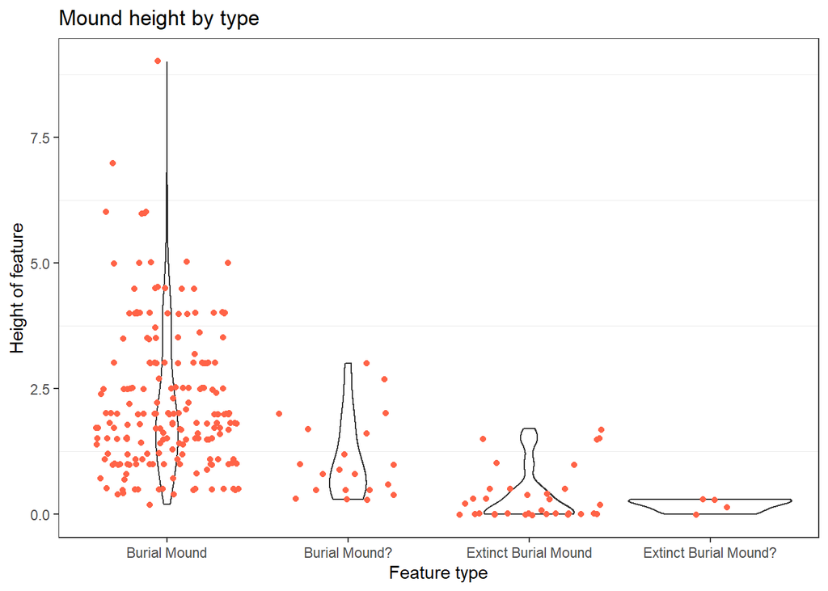

```r
mounds22 %>%
  ggplot(aes(x = TypeClean, y = HeightMax)) +
  geom_violin(alpha = 0)+
  geom_jitter(color = "tomato")+
  theme_bw()+
  theme(panel.grid.major = element_blank())+
  labs(x = "Feature type",
       y = "Height of feature",
       title = "Mound height by type")
```

### Source

Fix any aberrant values in the Source column by either overwriting them directly or by using `case_when()` function. Retain all values, but strip away comments and question marks make sure that the unique values at the end are `Survey`, `Legacy`, and `Serendipity`.

Tally the Source to see how large the groups are.

```r
# Clean up Source
unique(mounds22$Source)
```

```
## [1] "Legacy verification"
## [2] "Survey"
## [3] "Survey?"
## [4] "Survey (The mound is depicted in a top map M 1:5000 and is still visible on the satellite  maps.)"
## [5] "Serendipity"
```

```r
mounds22 <- mounds22 %>%
  mutate(Source = case_when(
    Source == "Legacy verification" ~ "Legacy",
    Source == "Survey (The mound is depicted in a top map M 1:5000 and is still visible on the satellite  maps.)" ~ "Survey",
    Source == "Survey?" ~ "Survey",
    Source == "Survey" ~ "Survey",
    Source == "Serendipity" ~ "Serendipity"
  ))

# Tally cleaned Source up
mounds22 %>%
  count(Source)
```

```
## # A tibble: 3 x 2
##   Source          n
##   <chr>       <int>
## 1 Legacy        207
## 2 Serendipity     4
## 3 Survey         41
```

Create boxplots/violins of mounds by Source and HeightMax, using the same theme as in the previous plot.

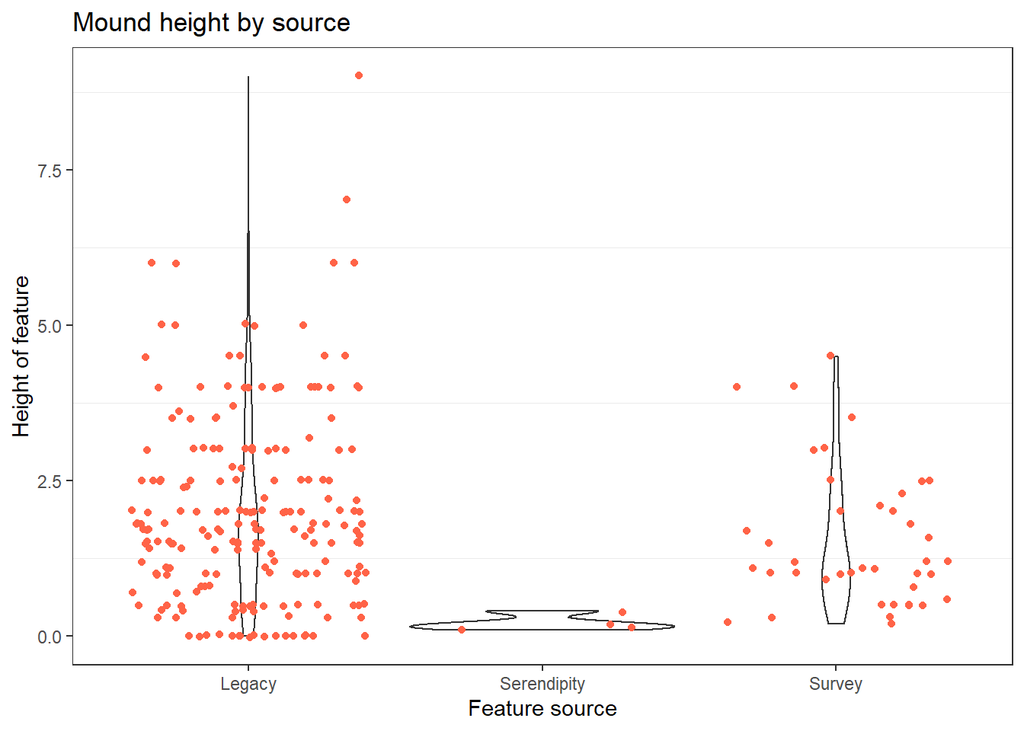

```r
mounds22 %>%
  ggplot(aes(x = Source, y = HeightMax)) +
  geom_violin(alpha = 0)+
  geom_jitter(color = "tomato")+
  theme_bw()+
  theme(panel.grid.major = element_blank())+
  labs(x = "Feature source",
       y = "Height of feature",
       title = "Mound height by source")
```

### Daily progress

Plot the progress of survey by day and feature source. You will first need to

- group the Date values (hint: `group_by()`)
- plot it using `geom_bar()`
- color the bars by `Source`
- set the theme to b&w

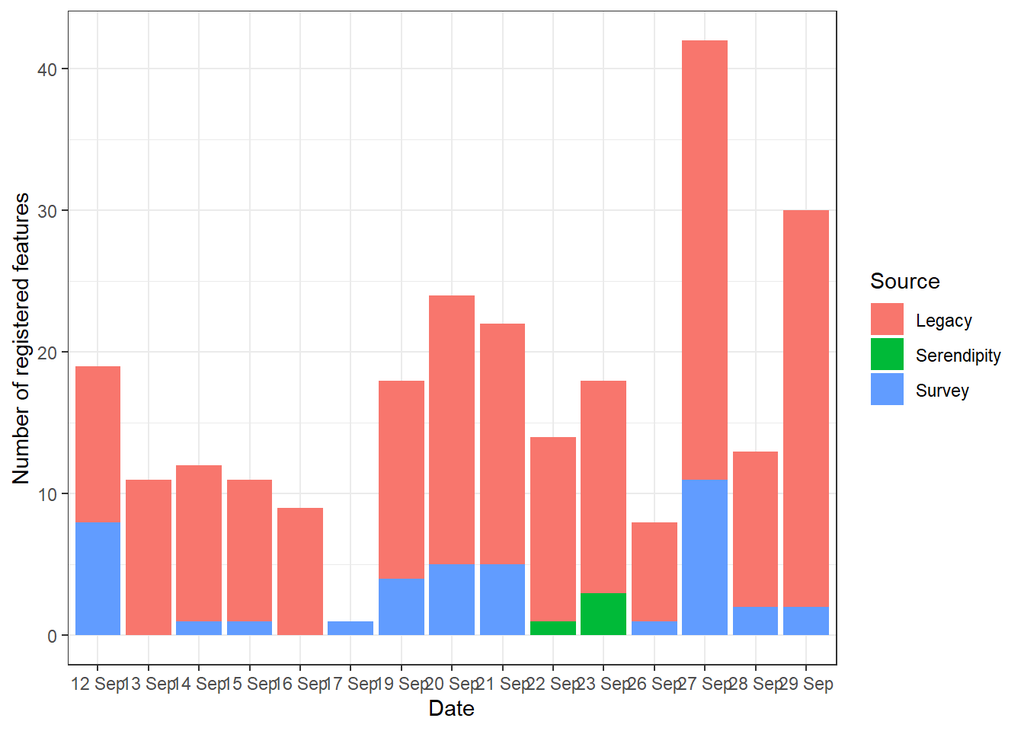

```r
mounds22 %>%
 group_by(Date) %>%
  ggplot(aes(x = Date))+
  geom_bar(aes(fill = Source))+
  theme_bw()+
  labs(y = "Number of registered features")
```

Looking at the chart, is the productivity of teams increasing or decreasing with time?

### Assess mound damage

If you have not yet reduced the Condition column to plain numbers from (0)1-5, do so now, using either `gsub()` or `substr()`.

Plot the Condition using `geom_barplot()`. - filter away Condition == 0, as it means value not available - flip the barplot on its side, showing the Condition bars horizontally - color the bars by Source - label axes meaningfully and set theme to bw

```r
unique(mounds22$Condition)
```

```
## [1] "4 - seriously damaged"
## [2] "5 - extinct or near extinct"
## [3] "2 - minor damage"
## [4] "3 - damaged"
## [5] "0 - No observation"
## [6] "1 - pristine"
## [7] "3 - damaged (01 trench is minor damage. the geodetic marker also creates damage )"
## [8] "0 - No observation (indeterminable due to scrub. possibly prestine)??"
```

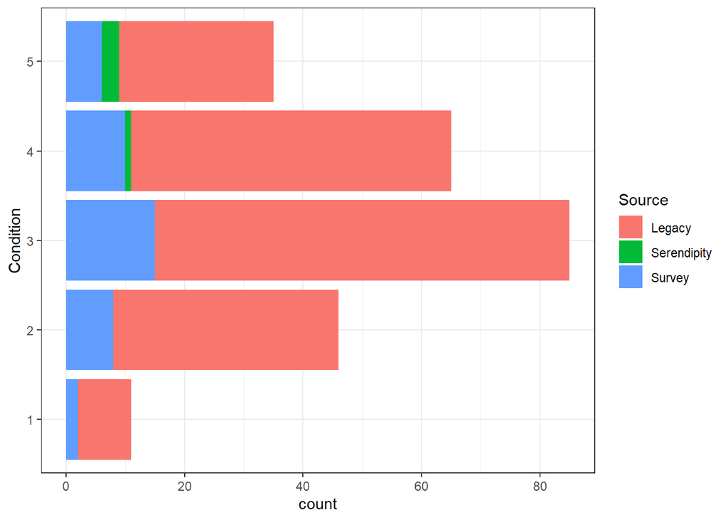

```r
mounds22 %>%
  #mutate(Condition = gsub("\\D","", Condition)) %>% # filter away non-digit characters
  mutate(Condition = substr(Condition, 1,1)) %>%  # grab only the first number
  filter(Condition != "0") %>%
  group_by(Condition) %>%
  ggplot(aes(x = Condition))+
  geom_bar(aes(fill = Source))+
  coord_flip()+
  theme_bw()
```

### How many mounds have been turned to bunkers?

Going to the original provided GoogleDrive dataset, search on Notes in Type (`Type Note`) that say `military|bunker` , case insensitive, to gauge the number of features which have been reused for military purposes.

After you figure out the number, print out a message stating the fraction of the mounds that were converted to military.

```r
# military subset
military <- m22 %>%
  filter(grepl("[Mm]ilitary|[Bb]unker",`Type Note`))

# message
paste0("During 2022, ",nrow(military), " of the verified ", nrow(mounds22), " features (",round(nrow(military)/nrow(mounds22)*100, digits=2),"%) were converted to military installations")
```

```
## [1] "During 2022, 12 of the verified 252 features (4.76%) were converted to military installations"
```